# Cyclistic Case Study Documentation

Author

Abdullah Mohsen

Published

December 13, 2025

## **Introduction**

This report analyzes *Cyclistic Bike Share* to understand how do annual members and casual rider use the bike share services differently?. The dataset contains trips start/end time, type of customers and the station names. The objective is to identify differences in behaviors and trends to enable data-driven strategies to optimize marketing.

## **Data Description**

- Origin: Downloaded from Divvy Bikes public data portal, to preview click the [poral](https://divvy-tripdata.s3.amazonaws.com/index.html) and under [license agreement](https://divvybikes.com/data-license-agreement) .
- Time Period: January 2019 to March 2019, and January 2020 to March 2020.
- File Format: Two CSV files, one per year, available as zip archive from the online portal.
- Collection Method: Automatically recorded by Divvys’ system and uploaded to the online portal.
- Access Details: Publicly accessible via [Divvy online poral](https://divvy-tripdata.s3.amazonaws.com/index.html).
- Reliability: the data is highly reliability as it sourced from Devvy bike share service system.
- Environment: RStudio for the analysis process and R Markdown for making the report. Using packages such as *‘tidyverse’*, *‘dplyr’* for processing and manipulation, *‘lubridate’* for date and time, *‘hms’* for formatting time-of-day values, *‘scales’* for scaling in plots and *‘ggplot2’* for visualization.

```r
library(tidyverse)
library(dplyr)
library(lubridate)
library(hms)
library(scales)
library(kableExtra)
library(ggplot2)
```

- Data Contents: the dataset *trips_2019* has 365,069 observations and 12 variables including start/end date and time, start/end station name and id, and user types,

```r
setwd("~/R/Case_Studies/Cyclistic/01_Data/Raw")
trips_2019 <- read.csv("Divvy_Trips_2019_Q1.csv")
trips_2020 <- read.csv("Divvy_Trips_2020_Q1.csv")
str(trips_2019)
```

```
'data.frame':   365069 obs. of  12 variables:
 $ trip_id          : int  21742443 21742444 21742445 21742446 21742447 21742448 21742449 21742450 21742451 21742452 ...
 $ start_time       : chr  "2019-01-01 0:04:37" "2019-01-01 0:08:13" "2019-01-01 0:13:23" "2019-01-01 0:13:45" ...
 $ end_time         : chr  "2019-01-01 0:11:07" "2019-01-01 0:15:34" "2019-01-01 0:27:12" "2019-01-01 0:43:28" ...
 $ bikeid           : int  2167 4386 1524 252 1170 2437 2708 2796 6205 3939 ...
 $ tripduration     : chr  "390" "441" "829" "1,783.00" ...
 $ from_station_id  : int  199 44 15 123 173 98 98 211 150 268 ...
 $ from_station_name: chr  "Wabash Ave & Grand Ave" "State St & Randolph St" "Racine Ave & 18th St" "California Ave & Milwaukee Ave" ...
 $ to_station_id    : int  84 624 644 176 35 49 49 142 148 141 ...
 $ to_station_name  : chr  "Milwaukee Ave & Grand Ave" "Dearborn St & Van Buren St (*)" "Western Ave & Fillmore St (*)" "Clark St & Elm St" ...
 $ usertype         : chr  "Subscriber" "Subscriber" "Subscriber" "Subscriber" ...
 $ gender           : chr  "Male" "Female" "Female" "Male" ...
 $ birthyear        : int  1989 1990 1994 1993 1994 1983 1984 1990 1995 1996 ...
```

and the dataset *trips_2020* has 426,887 observations and 13 variables, also includes start/end date and time, start/end station name and id, and user types.

```r
str(trips_2020)
```

```
'data.frame':   426887 obs. of  13 variables:
 $ ride_id           : chr  "EACB19130B0CDA4A" "8FED874C809DC021" "789F3C21E472CA96" "C9A388DAC6ABF313" ...
 $ rideable_type     : chr  "docked_bike" "docked_bike" "docked_bike" "docked_bike" ...
 $ started_at        : chr  "2020-01-21 20:06:59" "2020-01-30 14:22:39" "2020-01-09 19:29:26" "2020-01-06 16:17:07" ...
 $ ended_at          : chr  "2020-01-21 20:14:30" "2020-01-30 14:26:22" "2020-01-09 19:32:17" "2020-01-06 16:25:56" ...
 $ start_station_name: chr  "Western Ave & Leland Ave" "Clark St & Montrose Ave" "Broadway & Belmont Ave" "Clark St & Randolph St" ...
 $ start_station_id  : int  239 234 296 51 66 212 96 96 212 38 ...
 $ end_station_name  : chr  "Clark St & Leland Ave" "Southport Ave & Irving Park Rd" "Wilton Ave & Belmont Ave" "Fairbanks Ct & Grand Ave" ...
 $ end_station_id    : int  326 318 117 24 212 96 212 212 96 100 ...
 $ start_lat         : num  42 42 41.9 41.9 41.9 ...
 $ start_lng         : num  -87.7 -87.7 -87.6 -87.6 -87.6 ...
 $ end_lat           : num  42 42 41.9 41.9 41.9 ...
 $ end_lng           : num  -87.7 -87.7 -87.7 -87.6 -87.6 ...
 $ member_casual     : chr  "member" "member" "member" "member" ...
```

```r
colSums(is.na(trips_2019))
```

```
          trip_id        start_time          end_time            bikeid
                0                 0                 0                 0
     tripduration   from_station_id from_station_name     to_station_id
                0                 0                 0                 0
  to_station_name          usertype            gender         birthyear
                0                 0                 0             18023
```

there are three NA values in 2020 file, one at end_station_id which will excluded as it’s not relevent to this analysis, and two in end_lat and end_lng, these variables will also be excluded as they are not consistent in both data sources files,

```r
colSums(is.na(trips_2020))
```

```
           ride_id      rideable_type         started_at           ended_at
                 0                  0                  0                  0
start_station_name   start_station_id   end_station_name     end_station_id
                 0                  0                  0                  1
         start_lat          start_lng            end_lat            end_lng
                 0                  0                  1                  1
     member_casual
                 0
```

and there are no duplicate records found.

```r
nrow(trips_2019[duplicated(trips_2019),])
```

```
[1] 0
```

```r
nrow(trips_2020[duplicated(trips_2020),])
```

```
[1] 0
```

## **Processing Data**

- Standardizing and Processing NA Records: standardizing by keeping relevant variables and discarding NA records for both *trips_2019*, *trips_2020* datasets.

```r
trips_2019_v2 <- trips_2019 %>%
  select(trip_id,from_station_id,from_station_name,start_time,to_station_id,
         to_station_name,end_time,usertype) %>%
  na.omit()
trips_2020_v2 <- trips_2020 %>%
  select(ride_id,start_station_id,start_station_name,started_at,end_station_id,
         end_station_name,ended_at,member_casual) %>%
  na.omit()
```

- Consistency and Format:
  - Creating a function to deal with extracting date and time, calculating trip duration, fixing the negative *trip_length* where *end_time* is after midnight by adding 24h, filtering out records where *start_time* is the same as *end_time*, and return consistent unified column names and formatted data

```r
  #=== Function to extract date\time ===#
clean_and_duration <- function(
    df, start_col, end_col, station_from_col, station_to_col, user_col) {
  df %>%
    mutate(
      id = row_number(),
      start_at = ymd_hms({{ start_col }}),
      end_at = ymd_hms({{ end_col }}),
      year = year(start_at),
      month = month(start_at, label = TRUE, abbr = TRUE),
      day = wday(start_at, label = TRUE, abbr = TRUE),
      #=== Keep character string version for display ===#
      start_time = format(start_at, "%H:%M:%S"),
      end_time = format(end_at, "%H:%M:%S"),
      start_station_name = {{ station_from_col }},
      end_station_name = {{ station_to_col }},
      user_type = {{ user_col }},
      #=== Extract hms directly from POSIXct ===#
      start_hms = as_hms(start_at),
      end_hms = as_hms(end_at),
      trip_seconds = case_when(
        end_hms > start_hms ~ as.numeric(end_hms - start_hms),
        end_hms < start_hms ~ as.numeric(end_hms - start_hms) + 24 * 3600),
      trip_length = as_hms(trip_seconds)) %>%
    select(
      id, start_station_name, start_at, start_time, year, month, day, user_type,
      end_station_name, end_at, end_time, trip_length, trip_seconds)}
```

```r
trips_2019_v3 <- clean_and_duration(
  trips_2019_v2,
  start_time,
  end_time,
  from_station_name,
  to_station_name,
  usertype) %>%
  na.omit()

trips_2020_v3 <- clean_and_duration(
  trips_2020_v2,
  started_at,
  ended_at,
  start_station_name,
  end_station_name,
  member_casual) %>%
  na.omit()
```

- Appending *trips_2019* dataset and *trips_2020* dataset into *all_trips*

```r
all_trips <- bind_rows(trips_2019_v3,trips_2020_v3)
nrow(all_trips[duplicated(all_trips),])
```

```
[1] 0
```

```r
colSums(is.na(all_trips))
```

```
                id start_station_name           start_at         start_time
                 0                  0                  0                  0
              year              month                day          user_type
                 0                  0                  0                  0
  end_station_name             end_at           end_time        trip_length
                 0                  0                  0                  0
      trip_seconds
                 0
```

- Unifying *user_type* values for *user_type* from *member* and *Subscriber* into *Annual member* and from *casual* and *Customer* into *Casual rider*

```r
all_trips$user_type <- ifelse(all_trips$user_type %in% c('Subscriber','member'),
  'Annual member', 'Casual rider')
```

- Removing special characters found in station names except for *&* and *space*

```r
all_trips_v2 <- all_trips %>%
  mutate(start_station_name = gsub("[^[:alnum:]& ]", "", all_trips$start_station_name),
         end_station_name = gsub("[^[:alnum:]& ]", "", all_trips$end_station_name))
```

## **Analysis and Findings**

### **EDA**

- The total number of trips made and the average ride length is:

```r
all_trips_v2 %>%
  summarise(
    total_trips = n(),
    avg_duration_hms = as_hms(round(mean(trip_seconds) / 60) * 60),)
```

```
  total_trips avg_duration_hms
1      791862         00:14:00
```

- The summary of trips and duration for users by year:

```r
all_trips_v2 %>%
  group_by(year, user_type) %>%
  summarise(
    n_trips  = n(),
    avg_duration_min  = round(mean(trip_seconds / 60), 2), # Minutes, 2 decimals
    .groups = "drop")
```

```
# A tibble: 4 × 4
   year user_type     n_trips avg_duration_min
  <dbl> <chr>           <int>            <dbl>
1  2019 Annual member  341906             11.5
2  2019 Casual rider    23163             37.1
3  2020 Annual member  378407             11.6
4  2020 Casual rider    48386             43.6
```

- The weekly summary of trips and duration for the Casual rider:

```r
all_trips_v2 %>%
  filter(user_type == "Casual rider") %>%
  group_by(day) %>%
  summarise(
    n_trips  = n(),
    avg_duration_min  = round(mean(trip_seconds / 60), 2),
    .groups = "drop") %>%
  mutate(
    day = factor(day, levels = c("Mon", "Tue", "Wed", "Thu", "Fri", "Sat", "Sun")))
```

```
# A tibble: 7 × 3
  day   n_trips avg_duration_min
  <ord>   <int>            <dbl>
1 Sun     18652             43.8
2 Mon      6713             34.9
3 Tue      7979             36.3
4 Wed      8402             47.4
5 Thu      7802             41.2
6 Fri      8528             41.2
7 Sat     13473             41.6
```

- The most busiest day of the week by Casual rider:

```r
all_trips_v2 %>%
  filter(user_type == "Casual rider") %>%
  count(day, name = "n_trips") %>%
  arrange(desc(n_trips)) %>%
  slice(1)
```

```
  day n_trips
1 Sun   18652
```

- The top 5 most visited stations by the Casual rider:

```r
all_trips_v2 %>%
  filter(user_type == "Casual rider") %>%
  group_by(start_station_name) %>%
  summarize(trips = n()) %>%
  ungroup() %>%
  arrange(desc(trips)) %>%
  slice_head( n = 5)
```

```
# A tibble: 5 × 2
  start_station_name        trips
  <chr>                     <int>
1 HQ QR                      3672
2 Streeter Dr & Grand Ave    2749
3 Lake Shore Dr & Monroe St  2732
4 Shedd Aquarium             1832
5 Millennium Park            1406
```

### **Visualization**

- In 2020 the number of trips taken by Casual riders has increased to more than double the number of trips taken in 2019

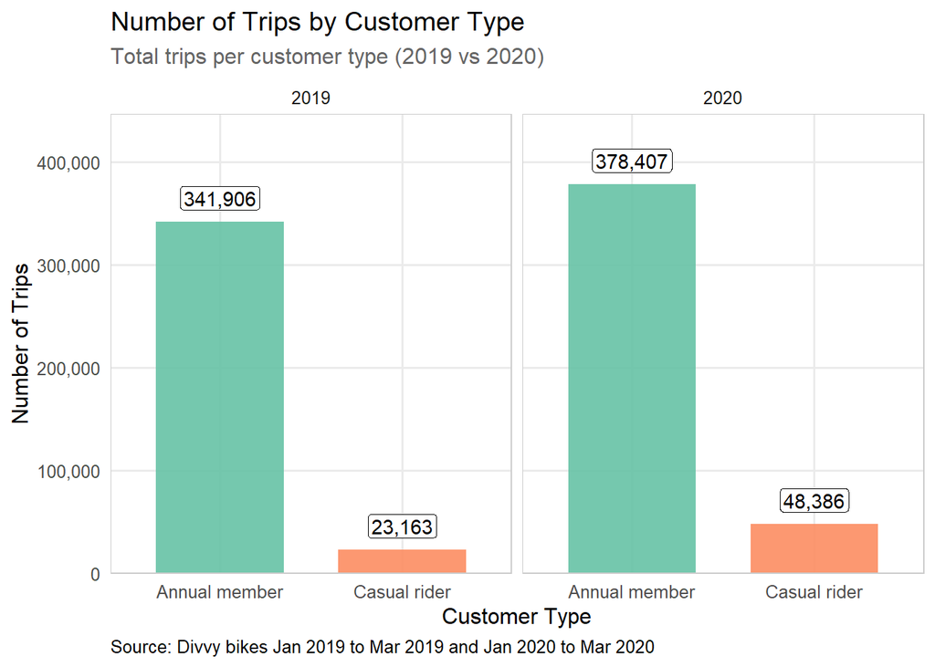

```r
ggplot(all_trips_v2, aes(x = user_type, fill = user_type)) +
  geom_bar(width = 0.7, alpha = 0.9) +
  geom_label(
    stat = "count",
    aes(label = scales::comma(after_stat(count))),
    vjust = -0.5,
    size = 3.8,
    fill = "white",
    linewidth = 0.25,
    label.padding = unit(0.15, "lines")) +
  facet_wrap(~ year) +
  scale_y_continuous(
    labels = scales::comma,
    expand = expansion(mult = c(0, 0.18))) +
  scale_fill_brewer(palette = "Set2") +
  labs(
    title = "Number of Trips by Customer Type",
    subtitle = "Total trips per customer type (2019 vs 2020)",
    x = "Customer Type",
    y = "Number of Trips",
    caption = "Source: Divvy bikes Jan 2019 to Mar 2019 and Jan 2020 to Mar 2020") +
  theme_minimal(base_size = 12) +
  theme(
    legend.position = "none",
    plot.subtitle = element_text(color = "gray40"),
    plot.caption = element_text(hjust = 0),
    panel.grid.minor = element_blank(),
    panel.border = element_rect(color = "gray80", fill = NA, linewidth = 0.5))
```

- The plot shows the average trip duration for Casual riders which is higher than the Annual members

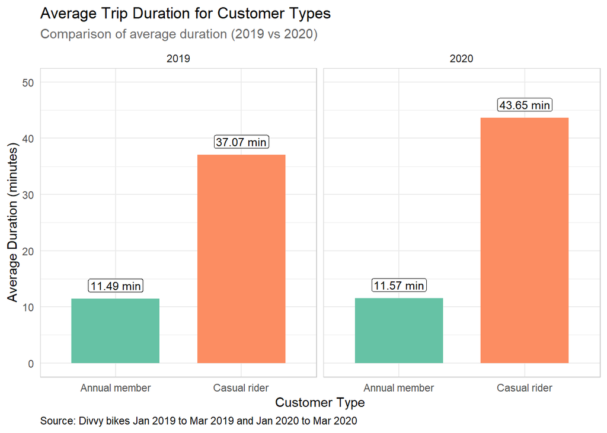

```r
avg_trip_summ <- all_trips_v2 %>%
  group_by(year, user_type) %>%
  summarise(
    n_trips  = n(),
    avg_duration_min  = round(mean(trip_seconds / 60), 2),
    .groups = "drop")

ggplot(avg_trip_summ, aes(x = user_type, y = avg_duration_min,
                                           fill = user_type)) +
  geom_col(width = 0.7) +
  geom_label(
    aes(label = paste(avg_duration_min, "min")),
    vjust = -0.5,
    size = 3.3,
    fill = "white",
    linewidth = 0.25,
    label.padding = unit(0.15, "lines"))+  facet_wrap(~ year) +
  #scale_y_continuous(breaks = seq(0, 60, 10)) +
  labs(
    title = "Average Trip Duration for Customer Types",
    subtitle = "Comparison of average duration (2019 vs 2020)",
    x = "Customer Type",
    y = "Average Duration (minutes)",
    caption = "Source: Divvy bikes Jan 2019 to Mar 2019 and Jan 2020 to Mar 2020") +
  scale_fill_brewer(palette = "Set2") +
  ylim(0,50)+
  theme_minimal() +
  guides(fill = "none") +
  theme(plot.subtitle = element_text(color = "gray40"),
        legend.position = "top",
        plot.caption = element_text(hjust = 0),
        panel.border = element_rect(color = "gray80", fill = NA, linewidth = 0.5))
```

- Annual members are mostly active during weekdays while Casual riders trips increase in the weekend

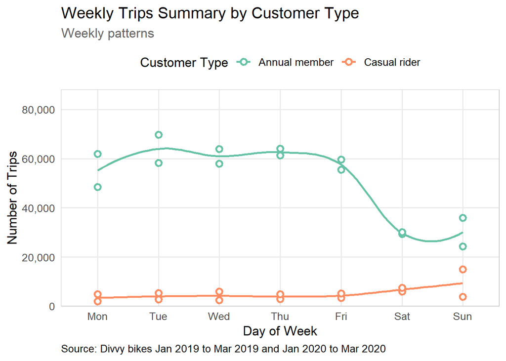

```r
avg_weekly_summ_user <- all_trips_v2 %>%
  group_by(year, user_type, day) %>%
  summarise(
    n_trips  = n(),
    avg_duration_min  = round(mean(trip_seconds / 60), 2),
    .groups = "drop") %>%
  mutate(
    day = factor(day, levels = c("Mon", "Tue", "Wed", "Thu", "Fri", "Sat", "Sun")))

ggplot(avg_weekly_summ_user, aes(x = day, y = n_trips,
                                                      color = user_type,
                                                      group = user_type)) +
  geom_smooth(se = FALSE, linewidth = 1, span = 0.6) +
  geom_point(size = 2, shape = 21, fill = "white", stroke = 1.5) +
  scale_y_continuous(
    labels = comma,
    limits = c(0, 80000),
    expand = expansion(mult = c(0, 0.1))) +
  scale_color_brewer(palette = "Set2") +
  labs(
    title = "Weekly Trips Summary by Customer Type",
    subtitle = "Weekly patterns",
    x = "Day of Week",
    y = "Number of Trips",
    caption = "Source: Divvy bikes Jan 2019 to Mar 2019 and Jan 2020 to Mar 2020",
    color = "Customer Type") +
  theme_minimal(base_size = 13) +
  theme(
    plot.subtitle = element_text(color = "gray40"),
    legend.position = "top",
    plot.caption = element_text(hjust = 0),
    panel.grid.minor = element_blank(),
    panel.border = element_rect(color = "gray80", fill = NA, linewidth = 0.5))
```

- The longest trip duration taken by Casual riders usually happens Wednesdays

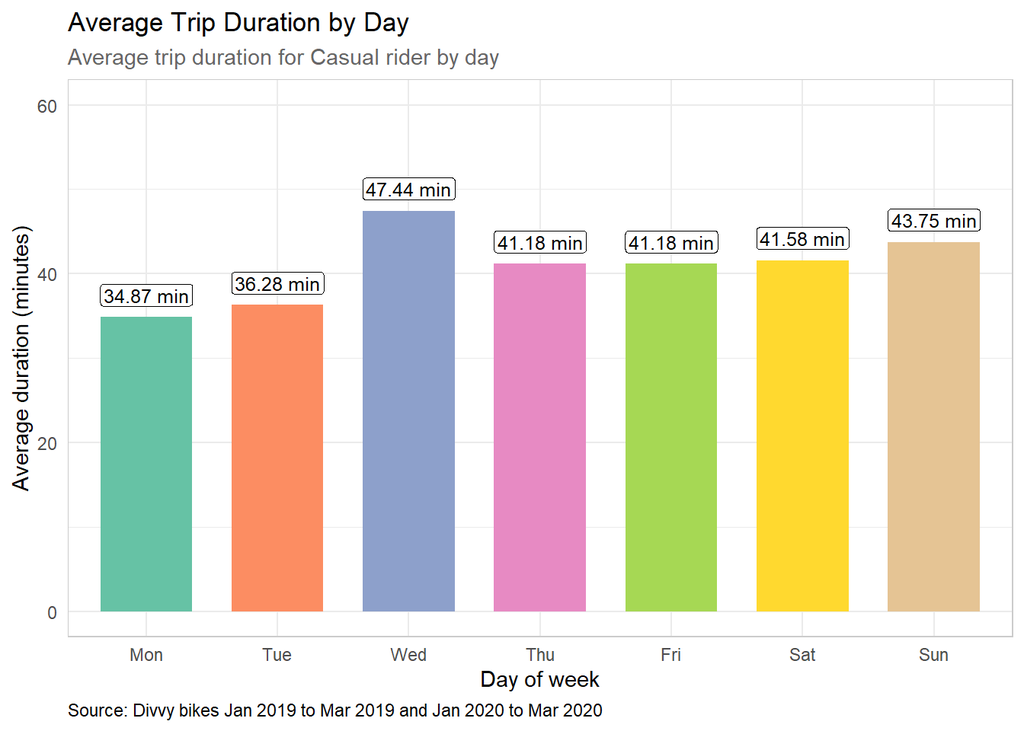

```r
avg_weekly_casual <- all_trips_v2 %>%
  filter(user_type == "Casual rider") %>%
  group_by(day) %>%
  summarise(
    n_trips  = n(),
    avg_duration_min  = round(mean(trip_seconds / 60), 2), # Minutes, 2 decimals
    .groups = "drop") %>%
  mutate(
    day = factor(day, levels = c("Mon", "Tue", "Wed", "Thu", "Fri", "Sat", "Sun")))

ggplot(avg_weekly_casual, aes(y = avg_duration_min,
                                                      x = day, fill = day)) +
  geom_col(width = 0.7) +
  geom_label(
    aes(label = paste(avg_duration_min, "min")),
    vjust = -0.5,
    size = 3.3,
    fill = "white",
    linewidth = 0.25,
    label.padding = unit(0.15, "lines"))+
  labs(
    x = "Day of week",
    y = "Average duration (minutes)",
    title = "Average Trip Duration by Day",
    subtitle = "Average trip duration for Casual rider by day",
    caption = "Source: Divvy bikes Jan 2019 to Mar 2019 and Jan 2020 to Mar 2020") +
  scale_fill_brewer(palette = "Set2") +
  ylim(0,60) +
  theme_minimal() +
  theme(plot.subtitle = element_text(color = "gray40"),
        legend.position = "none",
        plot.caption = element_text(hjust = 0),
        panel.border = element_rect(color = "gray80", fill = NA, linewidth = 0.5))
```

- Most busiest hours of the day for Casual riders is between 12pm to 5pm, and the peak hour is 3pm

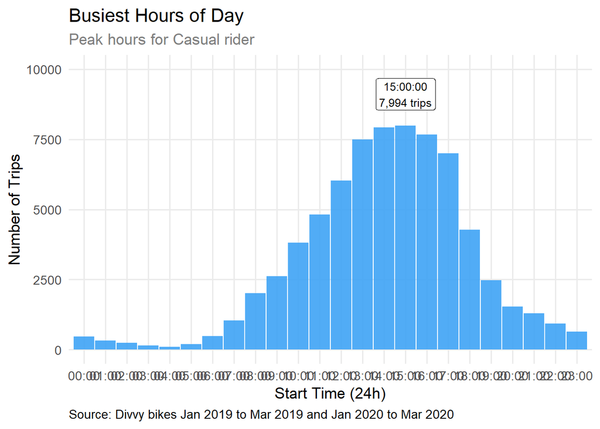

```r
trips_binned <- all_trips_v2 %>%
  filter(user_type == "Casual rider") %>%
  mutate(
    time_bin = floor_date(start_at, "1 hour"),
    time_of_day = as_hms(time_bin)) %>%
  count(time_of_day, name = "n") %>%
  complete(time_of_day = hms(seq(0, 23*3600, 3600)), fill = list(n = 0))

peak_hour <- trips_binned %>%
  slice_max(n, n = 1) %>%
  mutate(
    peak_label = paste0(format(time_of_day, "%H:%M"), "\n",
      scales::comma(n), " trips"))

ggplot(trips_binned, aes(x = time_of_day, y = n)) +
  geom_col(fill = "#42A5F5", width = 3400, alpha = 0.92) +  # ~1-hour width
  geom_label(
    data = peak_hour,
    aes(label = peak_label),
    vjust = -0.5,
    size = 3.3,
    fill = "white",
    linewidth = 0.3,
    label.padding = unit(0.25, "lines")) +
  scale_x_time(
    labels = time_format("%H:%M"),
    breaks = hms(hours = 0:23),
    expand = expansion(mult = c(0.01, 0.01))) +
  #scale_y_continuous(labels = comma, expand = expansion(mult = c(0, 0.18))) +
  ylim(0,10000) +
  labs(
    title = "Busiest Hours of Day",
    subtitle = "Peak hours for Casual rider",
    x = "Start Time (24h)",
    y = "Number of Trips",
    caption = "Source: Divvy bikes Jan 2019 to Mar 2019 and Jan 2020 to Mar 2020") +
  theme_minimal(base_size = 13) +
  theme(
    plot.subtitle = element_text(color = "gray50"),
    panel.grid.minor = element_blank(),
    plot.caption = element_text(hjust = 0),
    axis.text.x = element_text(angle = 0))
```

- The graph below show the top 5 stations most visited by Casual riders

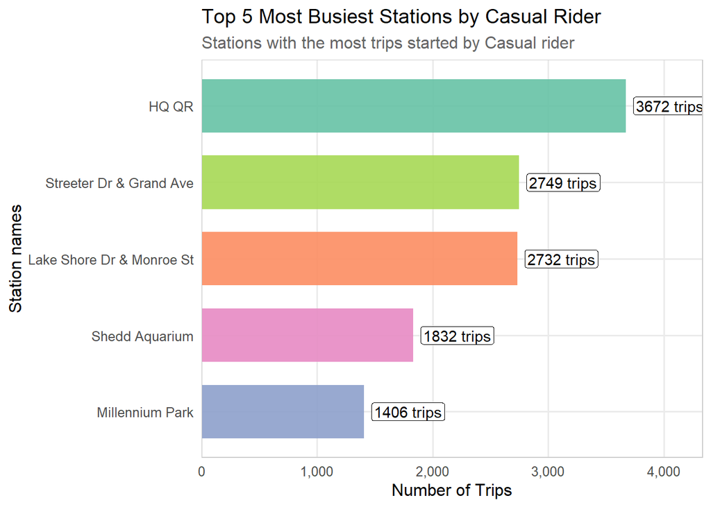

```r
busiest_stations_casual <- all_trips_v2 %>%
  filter(user_type == "Casual rider") %>%
  group_by(start_station_name) %>%
  summarize(trips = n()) %>%
  ungroup() %>%
  arrange(desc(trips)) %>%
  slice_head( n = 5)

ggplot(busiest_stations_casual,
                               aes(x = trips, y = reorder(start_station_name, trips),
                                   fill = start_station_name)) +
  geom_col(width = 0.7, alpha = 0.9) +
  geom_label(
    aes(label = paste(trips, "trips")),
    hjust = -0.1,
    size = 3.8,
    fill = "white",
    linewidth = 0.25,
    label.padding = unit(0.15, "lines")) +
  scale_x_continuous(
    labels = scales::comma,
    expand = expansion(mult = c(0, 0.18))) +
  scale_fill_brewer(palette = "Set2") +
  labs(
    title = "Top 5 Most Busiest Stations by Casual Rider",
    subtitle = "Stations with the most trips started by Casual rider",
    x = "Number of Trips",
    y = "Station names") +
  theme_minimal(base_size = 12) +
  theme(
    legend.position = "none",
    plot.subtitle = element_text(color = "gray40"),
    panel.grid.minor = element_blank(),
    panel.border = element_rect(color = "gray80", fill = NA, linewidth = 0.5))
```

## **Strategic Marketing Recommendations**

1. **Introduce Weekend Subscriptions for Casual Riders**

   Leverage the **Weekly Trips Summary by Customer Type** graph, which shows higher bike usage by casual riders on weekends. Offer targeted weekend-only membership plans to convert casual riders into recurring members, emphasizing convenience and cost savings for weekend rides.
2. **Targeted Advertising at High-Traffic Stations for Casual Riders**

   Based on the **Top 5 Most Busiest Stations by Casual Rider** graph, prioritize advertising at stations with the highest casual rider traffic. Promote membership upgrades or special offers, highlighting benefits like unlimited rides or discounts tailored to frequent casual riders.
3. **Launch Midday Promotions for Peak Hours**

   The **Busiest Hours of Day** graph indicates peak bike usage by casual riders between 12 PM and 5 PM. Introduce time-specific promotions, such as discounted rates or bonus ride time for trips taken during these hours.

## **Outcomes and Impact**

Through data analysis, Cyclistic can refine its marketing strategy to increase customer engagement of the bike-share services. By tailoring marketing efforts according to detailed customer behavior insights.

## **Conclusion**

The “Cyclistic Bike-Share Analysis for Targeted Marketing” case study underscores the significance of data in crafting precise marketing strategies. By understanding customer patterns and preferences, Cyclistic can deploy targeted campaigns that not only meet customer needs but also drive company growth and market competitiveness.